# Table of Contents

```python
from IPython.display import HTML

HTML('''<script>
code_show=true;
function code_toggle() {
 if (code_show){
 $('div.input').hide();
 } else {
 $('div.input').show();
 }
 code_show = !code_show
}
$( document ).ready(code_toggle);
</script>
<form action="javascript:code_toggle()"><input type="submit" value="Click here to toggle on/off the raw code."></form>''')
```

*Group project : Jeulin Marc, Romano Julien, Janvier Nils*

```python
import pandas as pd
import numpy as np
from scipy.stats import skew
from scipy.stats import norm, kurtosis
```

```python
from IPython.core.display import display, HTML
display(HTML("<style>.container { width:95% !important; }</style>"))
```

## Import data

### Vox data

```python
VOX_1 = pd.read_excel(r'vxoarchive.xls')
VOX_1 = VOX_1.drop(VOX_1.index[[0]])
VOX_1.columns = VOX_1.iloc[0]
VOX_1 = VOX_1.drop(VOX_1.index[[0]])
VOX_1 = VOX_1[['Date','Close']]

VOX_2 = pd.read_csv(r'vxocurrent.csv')
VOX_2 = VOX_2.drop(VOX_2.index[[0]])
VOX_2.columns =VOX_2.iloc[0]
VOX_2 = VOX_2[['Date    ','Close']]
VOX_2.columns = ['Date','Close']

VOX_2 = VOX_2.drop(VOX_2.index[[0]])

VOX = pd.concat([VOX_1, VOX_2])
VOX.reset_index(inplace=True,drop=True)
VOX['Date'] = pd.to_datetime(VOX['Date'])
VOX['month'] = VOX['Date'].dt.month
VOX['year'] = VOX['Date'].dt.year
VOX.Close = VOX.Close.astype(float)

agg_VOX = VOX.groupby(['month','year'])[['Close']].agg(min)
agg_VOX.reset_index(inplace=True)
agg_VOX = agg_VOX.rename(columns={'Close':'min'})

VOX = VOX.set_index('Date')
VOX = VOX.resample('M').last()
VOX = VOX.reset_index()

VOX = pd.merge(left=VOX, right=agg_VOX, left_on=['month','year'], right_on =['month','year'])
VOX['VREG'] = VOX['Close'] - VOX['min']
VOX = VOX.drop(columns={'month','year','min'})
VOX = VOX.rename(columns={'Close':'close', 'Date':'date'})
VOX = VOX.set_index('date')
VOX.columns = ['VOX', 'VREG']
VOX.index = pd.to_datetime(VOX.index, format='%Y%m').strftime('%Y-%m')
VOX
```

| date | VOX | VREG |
| --- | --- | --- |
| 1986-01 | 19.58 | 2.92 |
| 1986-02 | 21.59 | 3.63 |
| 1986-03 | 23.33 | 3.39 |
| 1986-04 | 21.69 | 0.63 |
| 1986-05 | 18.89 | 2.15 |
| ... | ... | ... |
| 2020-02 | 46.60 | 33.22 |
| 2020-03 | 54.57 | 22.28 |
| 2020-04 | 32.80 | 1.71 |
| 2020-05 | 27.24 | 0.36 |
| 2020-06 | 41.34 | 17.58 |

414 rows × 2 columns

### fama french 5 factors

```python
fama_french_5 = pd.read_csv(r'F-F_Research_Data_5_Factors_2x3.csv', sep=';').replace(',','', regex=True)
fama_french_5.Date = pd.to_datetime(fama_french_5.Date, format= '%Y%m')
fama_french_5.rename(columns={'Date': 'date'},
                       inplace=True)
fama_french_5 = fama_french_5.set_index('date')
fama_french_5.index = pd.to_datetime(fama_french_5.index, format='%Y%m').strftime('%Y-%m')
fama_french_5.columns = fama_french_5.columns + ' FAMA F.'
fama_french_5 = fama_french_5.astype(float)
```

### misp pricing factors

```python
misp_prices = pd.read_csv('M4.csv')
misp_prices.rename(columns={'YYYYMM': 'date'},
                       inplace=True)
misp_prices.date = pd.to_datetime(misp_prices.date, format= '%Y%m')
misp_prices.set_index('date', inplace=True)
misp_prices.index = pd.to_datetime(misp_prices.index, format='%Y%m').strftime('%Y-%m')
misp_prices.columns = misp_prices.columns + ' MISP Pricing'
misp_prices
```

| date | MKTRF MISP Pricing | SMB MISP Pricing | MGMT MISP Pricing | PERF MISP Pricing | RF MISP Pricing |
| --- | --- | --- | --- | --- | --- |
| 1963-01 | 0.0493 | 0.024818 | 0.021349 | -0.022751 | 0.0025 |
| 1963-02 | -0.0238 | 0.018096 | 0.010961 | 0.000874 | 0.0023 |
| 1963-03 | 0.0308 | -0.008183 | 0.005890 | 0.023281 | 0.0023 |
| 1963-04 | 0.0451 | -0.037328 | 0.000190 | 0.005077 | 0.0025 |
| 1963-05 | 0.0176 | 0.021518 | 0.017593 | 0.002848 | 0.0024 |
| ... | ... | ... | ... | ... | ... |
| 2016-08 | 0.0050 | 0.025444 | 0.018547 | -0.049411 | 0.0002 |
| 2016-09 | 0.0025 | 0.013134 | -0.009430 | -0.021728 | 0.0002 |
| 2016-10 | -0.0202 | -0.018153 | 0.032443 | 0.020009 | 0.0002 |
| 2016-11 | 0.0486 | 0.060455 | 0.048981 | -0.076985 | 0.0001 |
| 2016-12 | 0.0182 | 0.016927 | 0.004534 | 0.004859 | 0.0003 |

648 rows × 5 columns

### Q5 factors

```python
q5_factors= pd.read_csv('q5_factors_monthly_2019.csv')
# q5_factors.index = pd.to_datetime(q5_factors.index, format= '%Y%m')
q5_factors[['year', 'month']] = q5_factors[['year', 'month']].astype(str)
q5_factors['date'] = q5_factors[['year', 'month']].apply(lambda x: '-'.join(x), axis=1)
q5_factors.drop(['year', 'month'], axis=1, inplace=True)
q5_factors.set_index('date',inplace=True)
q5_factors.index = pd.to_datetime(q5_factors.index, format='%Y%m', infer_datetime_format=True).strftime('%Y-%m')
q5_factors.columns = q5_factors.columns + ' q5'
q5_factors
```

| date | R_F q5 | R_MKT q5 | R_ME q5 | R_IA q5 | R_ROE q5 | R_EG q5 |
| --- | --- | --- | --- | --- | --- | --- |
| 1967-01 | 0.3927 | 8.1603 | 6.7282 | -2.9434 | 1.8866 | -2.2469 |
| 1967-02 | 0.3743 | 0.7202 | 1.6918 | -0.2064 | 3.5317 | 2.5812 |
| 1967-03 | 0.3693 | 3.9691 | 1.9517 | -1.6933 | 1.8876 | -1.4789 |
| 1967-04 | 0.3344 | 3.8265 | -0.7446 | -2.9519 | 1.0983 | -2.2351 |
| 1967-05 | 0.3126 | -4.2419 | 2.9132 | 2.4686 | 0.5234 | 0.2749 |
| ... | ... | ... | ... | ... | ... | ... |
| 2019-08 | 0.1908 | -2.2179 | -4.2469 | -0.9351 | 1.7673 | 1.6305 |
| 2019-09 | 0.1787 | 1.4237 | 1.3935 | 3.0078 | 1.6828 | -2.0098 |
| 2019-10 | 0.1531 | 1.7734 | 0.8401 | -0.5515 | 0.6286 | 1.7170 |
| 2019-11 | 0.1197 | 3.3774 | -0.0261 | -1.0127 | -1.1667 | -0.3332 |
| 2019-12 | 0.1431 | 2.7017 | 1.2822 | 1.8360 | -1.3200 | -0.7981 |

636 rows × 6 columns

### liquidity factor

```python
liquidity_factor = pd.read_excel('liquidity.xlsx')
liquidity_factor.Month = pd.to_datetime(liquidity_factor.Month, format= '%Y%m')
liquidity_factor.rename(columns={'Month': 'date',
                                 'Innov Liq (eq8)': 'liq_eq8'},
                       inplace=True)
liquidity_factor.set_index('date', inplace=True)
liquidity_factor.index = pd.to_datetime(liquidity_factor.index, format='%Y%m',
                                  infer_datetime_format=True).strftime('%Y-%m')
liquidity_factor
```

| date | liq_eq8 |
| --- | --- |
| 1962-08 | 0.004260 |
| 1962-09 | 0.011461 |
| 1962-10 | -0.074826 |
| 1962-11 | 0.028615 |
| 1962-12 | 0.014584 |
| ... | ... |
| 2019-08 | 0.022677 |
| 2019-09 | -0.027019 |
| 2019-10 | 0.000715 |
| 2019-11 | 0.035754 |
| 2019-12 | 0.027985 |

689 rows × 1 columns

### DHS factors

```python
dhs_factor = pd.read_excel('DHS_factors.xlsx')
dhs_factor.date = pd.to_datetime(dhs_factor.date, format= '%Y%m')
dhs_factor.set_index('date', inplace=True)
dhs_factor.index = pd.to_datetime(dhs_factor.index, format='%Y%m',
                                  infer_datetime_format=True).strftime('%Y-%m')
dhs_factor
```

| date | PEAD | FIN |
| --- | --- | --- |
| 1972-07 | 0.734339 | 1.983935 |
| 1972-08 | -0.726892 | 3.787695 |
| 1972-09 | -0.322526 | 1.297314 |
| 1972-10 | 1.860766 | 3.085384 |
| 1972-11 | 1.845176 | 0.308475 |
| ... | ... | ... |
| 2018-08 | 5.766331 | -1.507146 |
| 2018-09 | 0.718196 | 0.130556 |
| 2018-10 | -0.209431 | 3.853901 |
| 2018-11 | 1.131172 | -1.993139 |
| 2018-12 | 1.315373 | 0.651167 |

558 rows × 2 columns

## Merge data

```python
list_df_to_merge = [VOX,
               fama_french_5,
               misp_prices,
               q5_factors,
               liquidity_factor,
                dhs_factor]


df_merged = list_df_to_merge[0]

for i in range(1,len(list_df_to_merge)):
    df_merged = pd.merge(df_merged, list_df_to_merge[i], left_on = df_merged.index,
                     right_on = list_df_to_merge[i].index, how= 'outer').rename(columns = {'key_0':'date'}).set_index('date')

df = df_merged.dropna()
df.head()
```

| date | VOX | VREG | Mkt-RF FAMA F. | SMB FAMA F. | HML FAMA F. | MW FAMA F. | CMA FAMA F. | RF FAMA F. | MKTRF MISP Pricing | SMB MISP Pricing | ... | RF MISP Pricing | R_F q5 | R_MKT q5 | R_ME q5 | R_IA q5 | R_ROE q5 | R_EG q5 | liq_eq8 | PEAD | FIN |
| --- | --- | --- | --- | --- | --- | --- | --- | --- | --- | --- | --- | --- | --- | --- | --- | --- | --- | --- | --- | --- | --- |
| 1986-01 | 19.58 | 2.92 | 0.65 | 1.01 | 0.53 | -2.02 | -2.05 | 0.56 | 0.0065 | 0.008302 | ... | 0.0056 | 0.4865 | 0.4964 | 1.0622 | -0.7089 | 1.7395 | 1.8057 | -0.036266 | 1.509397 | -2.966938 |
| 1986-02 | 21.59 | 3.63 | 7.13 | -0.76 | -0.94 | 1.15 | -1.39 | 0.53 | 0.0713 | -0.006418 | ... | 0.0053 | 0.5296 | 6.7204 | -0.4444 | -1.4614 | 2.2439 | 0.8796 | 0.019916 | 2.249367 | 0.150397 |
| 1986-03 | 23.33 | 3.39 | 4.88 | -0.57 | -0.44 | 1.12 | 0.99 | 0.60 | 0.0488 | 0.000879 | ... | 0.0060 | 0.5963 | 4.7922 | 0.6332 | 1.0696 | 2.0588 | 1.7284 | 0.044096 | 0.249108 | 0.867369 |
| 1986-04 | 21.69 | 0.63 | -1.31 | 2.92 | -2.85 | 2.91 | 0.02 | 0.52 | -0.0131 | 0.034933 | ... | 0.0052 | 0.5341 | -1.3244 | 1.0631 | -1.5629 | 0.6536 | 0.0689 | 0.023605 | 0.941834 | 1.352123 |
| 1986-05 | 18.89 | 2.15 | 4.62 | -1.26 | -0.11 | 2.08 | 1.11 | 0.49 | 0.0462 | -0.006861 | ... | 0.0049 | 0.4934 | 4.5910 | -1.1615 | 1.2742 | 3.4486 | 1.0156 | 0.018929 | 0.922871 | 3.010500 |

5 rows × 22 columns

## Analyse statistique de VREG

Prepare a summary statistics table showing the mean, std. dev. P1, P5, P25, P50, P75, P95, P99, skewness and kurtosis of your volatility-regret factor

```python
mean = df['VREG'].describe()['mean']
std = df['VREG'].describe()['std']
skewness = skew(df['VREG'])
kurtosis_ = kurtosis(df['VREG'])
P1 = df['VREG'].quantile(0.01)
P5 = df['VREG'].quantile(0.5)
P25 = df['VREG'].quantile(0.25)
P50 = df['VREG'].quantile(0.50)
P75 = df['VREG'].quantile(0.75)
P95 = df['VREG'].quantile(0.95)
P99 = df['VREG'].quantile(0.99)

stats_VREG = pd.DataFrame(data = {'mean'    : [mean],
                     'std'     : [std],
                     'skewness': [skewness],
                     'kurtosis': [kurtosis_],
                     'P1'      : [P1],
                     'P5'      : [P5],
                     'P25'     : [P25],
                     'P50'     : [P50],
                     'P75'     : [P75],
                     'P95'     : [P95],
                     'P99'     : [99]
                    }).T.rename(columns={0:'VREG'})
stats_VREG
```

[output not shown]

```python
corr = df[['Mkt-RF FAMA F.', 'SMB FAMA F.', 'HML FAMA F.',
       'MW FAMA F.', 'CMA FAMA F.', 'R_MKT q5', 'R_ME q5', 'R_IA q5',
       'R_ROE q5', 'R_EG q5']].corr()
corr.style.background_gradient(cmap='coolwarm')
```

|  | Mkt-RF FAMA F. | SMB FAMA F. | HML FAMA F. | MW FAMA F. | CMA FAMA F. | R_MKT q5 | R_ME q5 | R_IA q5 | R_ROE q5 | R_EG q5 |
| --- | --- | --- | --- | --- | --- | --- | --- | --- | --- | --- |
| Mkt-RF FAMA F. | 1.000000 | 0.200171 | -0.211835 | -0.373493 | -0.375284 | 0.998227 | 0.213235 | -0.351203 | -0.334545 | -0.438114 |
| SMB FAMA F. | 0.200171 | 1.000000 | -0.132372 | -0.443127 | -0.073628 | 0.208169 | 0.972507 | -0.172465 | -0.398633 | -0.407018 |
| HML FAMA F. | -0.211835 | -0.132372 | 1.000000 | 0.329585 | 0.658713 | -0.209487 | -0.081562 | 0.673685 | 0.073113 | 0.164492 |
| MW FAMA F. | -0.373493 | -0.443127 | 0.329585 | 1.000000 | 0.210422 | -0.381958 | -0.431423 | 0.281226 | 0.717893 | 0.591966 |
| CMA FAMA F. | -0.375284 | -0.073628 | 0.658713 | 0.210422 | 1.000000 | -0.374880 | -0.045894 | 0.915384 | 0.069138 | 0.268971 |
| R_MKT q5 | 0.998227 | 0.208169 | -0.209487 | -0.381958 | -0.374880 | 1.000000 | 0.220005 | -0.353940 | -0.349681 | -0.450112 |
| R_ME q5 | 0.213235 | 0.972507 | -0.081562 | -0.431423 | -0.045894 | 0.220005 | 1.000000 | -0.141087 | -0.312182 | -0.365398 |
| R_IA q5 | -0.351203 | -0.172465 | 0.673685 | 0.281226 | 0.915384 | -0.353940 | -0.141087 | 1.000000 | 0.137828 | 0.298050 |
| R_ROE q5 | -0.334545 | -0.398633 | 0.073113 | 0.717893 | 0.069138 | -0.349681 | -0.312182 | 0.137828 | 1.000000 | 0.585454 |
| R_EG q5 | -0.438114 | -0.407018 | 0.164492 | 0.591966 | 0.268971 | -0.450112 | -0.365398 | 0.298050 | 0.585454 | 1.000000 |

## Estimate stocks’ monthly VREG exposures via time-series regressions over 60-month rolling windows:

```python
df_reg = df[['VOX', 'VREG', 'Mkt-RF FAMA F.', 'SMB FAMA F.', 'HML FAMA F.', 'MW FAMA F.', 'CMA FAMA F.']]
df_reg
```

| date | VOX | VREG | Mkt-RF FAMA F. | SMB FAMA F. | HML FAMA F. | MW FAMA F. | CMA FAMA F. |
| --- | --- | --- | --- | --- | --- | --- | --- |
| 1986-01 | 19.58 | 2.92 | 0.65 | 1.01 | 0.53 | -2.02 | -2.05 |
| 1986-02 | 21.59 | 3.63 | 7.13 | -0.76 | -0.94 | 1.15 | -1.39 |
| 1986-03 | 23.33 | 3.39 | 4.88 | -0.57 | -0.44 | 1.12 | 0.99 |
| 1986-04 | 21.69 | 0.63 | -1.31 | 2.92 | -2.85 | 2.91 | 0.02 |
| 1986-05 | 18.89 | 2.15 | 4.62 | -1.26 | -0.11 | 2.08 | 1.11 |
| ... | ... | ... | ... | ... | ... | ... | ... |
| 2016-08 | 12.15 | 1.83 | 0.50 | 1.72 | 3.34 | -1.33 | -0.39 |
| 2016-09 | 13.30 | 2.98 | 0.25 | 1.74 | -1.49 | -2.29 | -0.08 |
| 2016-10 | 18.25 | 5.76 | -2.02 | -4.01 | 4.16 | 1.19 | 0.24 |
| 2016-11 | 13.32 | 1.52 | 4.86 | 6.81 | 8.29 | -0.10 | 3.70 |
| 2016-12 | 13.43 | 2.80 | 1.82 | 0.41 | 3.58 | 0.99 | -0.30 |

372 rows × 7 columns

```python
stocks = pd.read_pickle('./stocks/data_stocks')
stocks = stocks.loc[stocks.date >= "1986-01-01"]
stocks = stocks[['PERMNO', 'RET','date', 'annual_return','market_cap']]
stocks = stocks.set_index('date')
stocks.index = pd.to_datetime(stocks.index.astype(str), format='%Y-%m-%d', infer_datetime_format=True).strftime('%Y-%m')

df_agg = stocks.reset_index().groupby(['PERMNO'])[['RET']].agg('count')
PERMNO_to_keep = df_agg.loc[df_agg.RET > 300].index.unique()
stocks = stocks.loc[stocks.PERMNO.isin(PERMNO_to_keep)]
print(len(stocks.PERMNO.unique()))

stocks
```

```
1697
```

| date | PERMNO | RET | annual_return | market_cap |
| --- | --- | --- | --- | --- |
| 1986-01 | 31077 | -0.072626 | 0.432000 | 161393.50 |
| 1986-02 | 31077 | -0.018072 | 0.037500 | 158476.75 |
| 1986-03 | 31077 | 0.120000 | -0.084270 | 176113.00 |
| 1986-04 | 31077 | -0.077348 | 0.152866 | 162491.00 |
| 1986-05 | 31077 | -0.059880 | 0.043750 | 152761.00 |
| ... | ... | ... | ... | ... |
| 2019-08 | 79866 | -0.161566 | -0.191806 | 585912.96 |
| 2019-09 | 79866 | -0.066847 | -0.159772 | 546746.24 |
| 2019-10 | 79866 | 0.032914 | -0.236229 | 564763.10 |
| 2019-11 | 79866 | 0.018627 | -0.206691 | 570320.75 |
| 2019-12 | 79866 | 0.006033 | -0.230632 | 573761.20 |

627053 rows × 4 columns

```python
from sklearn.linear_model import LinearRegression
from sklearn.model_selection import train_test_split

from dateutil.relativedelta import relativedelta


def compute_reg(date, PERMNO, df = df_reg, df_stocks = stocks):

    df_stocks = df_stocks.loc[df_stocks['PERMNO'] == PERMNO]
    df_stocks = df_stocks.loc[pd.to_datetime(df_stocks.index) < date]
    df_stocks = df_stocks.loc[pd.to_datetime(df_stocks.index) >= (pd.to_datetime(date) - relativedelta(months=60))]

    temp_df = pd.merge(left=df, right=df_stocks,
                      left_on=df.index, right_on=df_stocks.index).rename(columns={'key_0':'date'}).drop(columns={'date'})

    temp_df = temp_df.dropna()

    X = temp_df.iloc[:,:-1].values
    y = temp_df.iloc[:,-1].values

    try:

        X_train, X_test, y_train, y_test = train_test_split(X, y, test_size = 1/3, random_state = 0)

        regressor = LinearRegression()
        regressor.fit(X_train,y_train)
        y_pred = regressor.predict(X_test)

        beta_vreg = regressor.coef_[1]

    except:
        beta_vreg = np.nan

    return date, PERMNO, beta_vreg



def get_beta_reg(df_stocks = stocks):

    list_beta = []

    for PERMNO in df_stocks['PERMNO'].unique():
        for date in df_stocks.index.unique()[60:]:

            list_beta.append(pd.DataFrame([compute_reg(date, PERMNO)]))

    df = pd.concat([x for x in list_beta])
    df.columns = ['date', 'PERMNO', 'beta_vreg']
    return df
```

## Portflolio Construction

```python
#df = get_beta_reg()
#df.to_pickle('beta_vref_by_PERMNO.pkl')
df = pd.read_pickle('beta_vreg_by_PERMNO.pkl')
df.reset_index(drop=True, inplace = True)
#df.set_index('date', inplace = True)
df.columns = ['date', 'PERMNO', 'beta_vreg']
df = pd.merge(left=df, right=stocks.reset_index()[['date', 'PERMNO','annual_return','market_cap']], left_on = ['date', 'PERMNO'],
                     right_on = ['date', 'PERMNO'], how= 'left')
```

For each month from January 1986 (1990) to December 2019, sort stocks into quintile portfolios based on their βVREG

```python
df = df.dropna()
df['quintile'] = pd.qcut(df.groupby('date')['beta_vreg'].rank(pct=True, ascending=False), 5, labels=False) + 1
df.reset_index(drop=True, inplace = True)
```

Calculate next-month average value-weighted and equally-weighted quintile portfolio returns, as well as the return on the zero-cost arbitrage portfolio that is long in the quintile of stocks with the highest βVREG and short in VREG the quintile of stocks with the lowest β

### Portofolio / Equally Weighted

shift the returns :

```python
df["annual_next_month_ret"] = df.annual_return.shift(-1)
remove_last_month = df.index[~df['PERMNO'].duplicated()].to_list()
remove_last_month = list(np.array(remove_last_month) - 1)
df.iloc[remove_last_month,5] = np.nan
```

```python
ptf_equ = df.groupby(['date', 'quintile'])[['annual_next_month_ret']].mean()
ptf_equ[:40]
```

| date | quintile | annual_next_month_ret |
| --- | --- | --- |
| 1991-01 | 1.0 | -0.289993 |
|  | 2.0 | -0.201947 |
|  | 3.0 | -0.115680 |
|  | 4.0 | -0.089748 |
|  | 5.0 | -0.210201 |
| 1991-02 | 1.0 | -0.159877 |
|  | 2.0 | -0.147289 |
|  | 3.0 | 0.142563 |
|  | 4.0 | -0.004933 |
|  | 5.0 | -0.107173 |
| 1991-03 | 1.0 | 0.057628 |
|  | 2.0 | -0.120817 |
|  | 3.0 | -0.005154 |
|  | 4.0 | -0.106175 |
|  | 5.0 | -0.006519 |
| 1991-04 | 1.0 | 0.215790 |
|  | 2.0 | -0.141664 |
|  | 3.0 | -0.049960 |
|  | 4.0 | -0.026378 |
|  | 5.0 | -0.085073 |
| 1991-05 | 1.0 | 0.180628 |
|  | 2.0 | -0.022921 |
|  | 3.0 | -0.090569 |
|  | 4.0 | -0.091028 |
|  | 5.0 | -0.105905 |
| 1991-06 | 1.0 | 0.222647 |
|  | 2.0 | -0.111425 |
|  | 3.0 | -0.086154 |
|  | 4.0 | -0.054406 |
|  | 5.0 | -0.192859 |
| 1991-07 | 1.0 | -0.083008 |
|  | 2.0 | -0.102726 |
|  | 3.0 | -0.052697 |
|  | 4.0 | -0.140590 |
|  | 5.0 | 0.209390 |
| 1991-08 | 1.0 | -0.467570 |
|  | 2.0 | -0.154661 |
|  | 3.0 | 0.014845 |
|  | 4.0 | -0.085196 |
|  | 5.0 | -0.074334 |

### Portofolio / Value Weighted

```python
total_market_cap = df.groupby(['date','quintile'])[['market_cap']].sum().rename(columns = {'market_cap' : 'total_quintile_mc'})
```

```python
total_market_cap.reset_index()
```

|  | date | quintile | total_quintile_mc |
| --- | --- | --- | --- |
| 0 | 1991-01 | 1.0 | 9.392095e+07 |
| 1 | 1991-01 | 2.0 | 5.685940e+08 |
| 2 | 1991-01 | 3.0 | 5.108790e+08 |
| 3 | 1991-01 | 4.0 | 3.926484e+08 |
| 4 | 1991-01 | 5.0 | 1.118897e+08 |
| ... | ... | ... | ... |
| 1730 | 2019-11 | 1.0 | 1.129549e+09 |
| 1731 | 2019-11 | 2.0 | 5.554225e+09 |
| 1732 | 2019-11 | 3.0 | 7.229357e+09 |
| 1733 | 2019-11 | 4.0 | 5.126278e+09 |
| 1734 | 2019-11 | 5.0 | 1.779772e+09 |

1735 rows × 3 columns

```python
ptf_vw = pd.merge(left=df, right=total_market_cap.reset_index()[['date','quintile','total_quintile_mc']],
                  left_on = ['date', 'quintile'],
                  right_on = ['date', 'quintile'], how= 'left')
```

```python
ptf_vw['vw'] = ptf_vw['annual_next_month_ret']*ptf_vw['market_cap']/ptf_vw['total_quintile_mc']
```

```python
ptf_vw.groupby(['date','quintile'])[['vw']].sum()
```

| date | quintile | vw |
| --- | --- | --- |
| 1991-01 | 1.0 | -0.084631 |
|  | 2.0 | 0.034940 |
|  | 3.0 | 0.042635 |
|  | 4.0 | 0.075319 |
|  | 5.0 | 0.103444 |
| ... | ... | ... |
| 2019-11 | 1.0 | 0.119041 |
|  | 2.0 | 0.222207 |
|  | 3.0 | 0.148451 |
|  | 4.0 | 0.133550 |
|  | 5.0 | 0.151189 |

1735 rows × 1 columns

### Portfolio / arbitrage

```python
first_quintile = ptf_equ[ptf_equ.index.get_level_values('quintile') == 1.0]
```

```python
last_quintile = ptf_equ[ptf_equ.index.get_level_values('quintile') == 5.0]
```

```python
df_arbitrage = pd.merge(left=first_quintile.reset_index(), right=last_quintile.reset_index()[['date','annual_next_month_ret']], left_on = ['date'],
                     right_on = ['date'], how= 'left').drop(columns={'quintile'})
df_arbitrage.rename(columns={'annual_next_month_ret_x' : "return_first_quintile",
                             'annual_next_month_ret_y' : "return_last_quintile"},
                    inplace = True)
df_arbitrage['arbitrage_ptf_return'] = df_arbitrage['return_first_quintile'] - df_arbitrage['return_last_quintile']
df_arbitrage
```

|  | date | return_first_quintile | return_last_quintile | arbitrage_ptf_return |
| --- | --- | --- | --- | --- |
| 0 | 1991-01 | -0.289993 | -0.210201 | -0.079793 |
| 1 | 1991-02 | -0.159877 | -0.107173 | -0.052704 |
| 2 | 1991-03 | 0.057628 | -0.006519 | 0.064148 |
| 3 | 1991-04 | 0.215790 | -0.085073 | 0.300863 |
| 4 | 1991-05 | 0.180628 | -0.105905 | 0.286534 |
| ... | ... | ... | ... | ... |
| 342 | 2019-07 | -0.080822 | 0.028846 | -0.109668 |
| 343 | 2019-08 | -0.194517 | -0.106072 | -0.088444 |
| 344 | 2019-09 | -0.100543 | 0.071009 | -0.171551 |
| 345 | 2019-10 | -0.013572 | 0.054918 | -0.068490 |
| 346 | 2019-11 | 0.128594 | 0.065554 | 0.063040 |

347 rows × 4 columns

## FVREG

Use the mimicking factor methodology as outlined in Fama and French (1993).  
Each month from January 1991 (1995) to December 2019, construct 6 (2x3) portfolios based on the intersections of 2 portfolios formed on size (market equity) and 3 portfolios formed on VREG.  
The monthly size breakpoint is the median NYSE market equity (ME), and the monthly VREG breakpoints are the 30th and 70th NYSE VREG percentiles.

```python
df = df[['date', 'PERMNO', 'beta_vreg', 'annual_return', 'market_cap','annual_next_month_ret']]
df
```

|  | date | PERMNO | beta_vreg | annual_return | market_cap | annual_next_month_ret |
| --- | --- | --- | --- | --- | --- | --- |
| 0 | 1991-01 | 31077 | 0.000316 | -0.075758 | 130029.875 | 0.217742 |
| 1 | 1991-02 | 31077 | -0.003503 | 0.217742 | 136057.750 | 0.082192 |
| 2 | 1991-03 | 31077 | -0.001258 | 0.082192 | 154011.375 | 0.340426 |
| 3 | 1991-04 | 31077 | -0.002091 | 0.340426 | 148307.250 | 0.263889 |
| 4 | 1991-05 | 31077 | -0.001039 | 0.263889 | 133639.500 | -0.052023 |
| ... | ... | ... | ... | ... | ... | ... |
| 557173 | 2019-08 | 79866 | 0.014418 | -0.191806 | 585912.960 | -0.159772 |
| 557174 | 2019-09 | 79866 | 0.000285 | -0.159772 | 546746.240 | -0.236229 |
| 557175 | 2019-10 | 79866 | 0.017840 | -0.236229 | 564763.100 | -0.206691 |
| 557176 | 2019-11 | 79866 | 0.023729 | -0.206691 | 570320.750 | -0.230632 |
| 557177 | 2019-12 | 79866 | 0.029092 | -0.230632 | 573761.200 | NaN |

557178 rows × 6 columns

```python
df['size_cap'] = pd.qcut(df.groupby('date')['market_cap'].rank(pct=True, ascending=False), 2, labels=False) + 1
df['size_beta'] = pd.qcut(x = df.groupby('date')['beta_vreg'].rank(pct=True, ascending=False),
                          q = [0, .3, .7, 1.],
                          labels=False) + 1
```

```python
ptf_6 = df.groupby(['date','size_cap','size_beta'])[['annual_next_month_ret']].mean()
```

```python
ptf_6.rename(columns = {'annual_next_month_ret' : 'ptf_annual_next_month_ret'},
             inplace= True)
```

```python
ptf_6.reset_index(inplace=True)
ptf_6
```

|  | date | size_cap | size_beta | ptf_annual_next_month_ret |
| --- | --- | --- | --- | --- |
| 0 | 1991-01 | 1 | 1 | -0.077199 |
| 1 | 1991-01 | 1 | 2 | -0.007977 |
| 2 | 1991-01 | 1 | 3 | 0.105538 |
| 3 | 1991-01 | 2 | 1 | -0.401423 |
| 4 | 1991-01 | 2 | 2 | -0.313474 |
| ... | ... | ... | ... | ... |
| 2083 | 2019-12 | 1 | 2 | -0.202869 |
| 2084 | 2019-12 | 1 | 3 | -0.240619 |
| 2085 | 2019-12 | 2 | 1 | -0.202512 |
| 2086 | 2019-12 | 2 | 2 | 0.253985 |
| 2087 | 2019-12 | 2 | 3 | -0.687188 |

2088 rows × 4 columns

```python
dct = {(1, 1): 'small_lo_beta',
       (1, 2): 'small_me_beta',
       (1, 3): 'small_hi_beta',
       (2, 1): 'big_lo_beta',
       (2, 2): 'big_me_beta',
       (2, 3): 'big_hi_beta'}
```

```python
ptf_6['ptf'] = ptf_6.set_index(['size_cap', 'size_beta']).index.map(dct.get)
```

```python
ptf_6.drop(columns=['size_cap', 'size_beta'],
           inplace = True)
```

```python
ptf_6[:13]
```

|  | date | ptf_annual_next_month_ret | ptf |
| --- | --- | --- | --- |
| 0 | 1991-01 | -0.077199 | small_lo_beta |
| 1 | 1991-01 | -0.007977 | small_me_beta |
| 2 | 1991-01 | 0.105538 | small_hi_beta |
| 3 | 1991-01 | -0.401423 | big_lo_beta |
| 4 | 1991-01 | -0.313474 | big_me_beta |
| 5 | 1991-01 | -0.378432 | big_hi_beta |
| 6 | 1991-02 | -0.032314 | small_lo_beta |
| 7 | 1991-02 | 0.054083 | small_me_beta |
| 8 | 1991-02 | 0.150372 | small_hi_beta |
| 9 | 1991-02 | -0.258491 | big_lo_beta |
| 10 | 1991-02 | -0.006964 | big_me_beta |
| 11 | 1991-02 | -0.234801 | big_hi_beta |
| 12 | 1991-03 | 0.000689 | small_lo_beta |

```python
print(f"small_lo_beta average return : {ptf_6[ptf_6['ptf'] == 'small_lo_beta'].mean()[0] : .5f} \n\
small_me_beta average return : {ptf_6[ptf_6['ptf'] == 'small_me_beta'].mean()[0] : .5f} \n\
small_hi_beta average return : {ptf_6[ptf_6['ptf'] == 'small_hi_beta'].mean()[0] : .5f} \n\
big_lo_beta average return   : {ptf_6[ptf_6['ptf'] == 'big_lo_beta'].mean()[0] : .5f} \n\
big_me_beta average return   : {ptf_6[ptf_6['ptf'] == 'big_me_beta'].mean()[0] : .5f} \n\
big_hi_beta average return   : {ptf_6[ptf_6['ptf'] == 'big_hi_beta'].mean()[0] : .5f} \n\
")
```

```
small_lo_beta average return :  0.14861
small_me_beta average return :  0.08882
small_hi_beta average return :  0.14215
big_lo_beta average return   :  0.00893
big_me_beta average return   : -0.08011
big_hi_beta average return   :  0.02401
```

```python
FVREG = 1/2*(
    ptf_6[ptf_6.ptf == 'small_lo_beta'][["ptf_annual_next_month_ret"]].reset_index(drop=True) + \
    ptf_6[ptf_6.ptf == 'big_lo_beta'][["ptf_annual_next_month_ret"]].reset_index(drop=True) - \
    ptf_6[ptf_6.ptf == 'small_hi_beta'][["ptf_annual_next_month_ret"]].reset_index(drop=True) - \
    ptf_6[ptf_6.ptf == 'big_hi_beta'][["ptf_annual_next_month_ret"]].reset_index(drop=True)
    )
```

```python
FVREG
```

|  | ptf_annual_next_month_ret |
| --- | --- |
| 0 | -0.102864 |
| 1 | -0.103188 |
| 2 | 0.038181 |
| 3 | 0.160076 |
| 4 | 0.219677 |
| ... | ... |
| 343 | -0.068694 |
| 344 | -0.148717 |
| 345 | 0.007304 |
| 346 | 0.039632 |
| 347 | 0.244867 |

348 rows × 1 columns

```python
print(f'FVREG factor : {FVREG["ptf_annual_next_month_ret"].mean() : .5f}')
```

```
FVREG factor : -0.00432
```

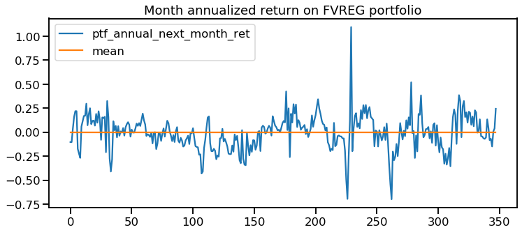

```python
%matplotlib inline
import seaborn as sns
import matplotlib.pyplot as plt

sns.set_context('talk')

fig, axs = plt.subplots(1,1,figsize=(12,5))
FVREG['mean'] = FVREG.ptf_annual_next_month_ret.mean()
FVREG.plot(ax=axs, title='Month annualized return on FVREG portfolio')
```

## FVREG explanation

```python
# pq pas un dict plutot
factor_models = {'dhs_factor' : dhs_factor , 'q5_factors' : q5_factors, 'misp_prices' : misp_prices, 'fama_french_5' : fama_french_5}
```

```python
FVREG['date'] = ptf_6.date.unique()
FVREG = FVREG.drop(columns={'mean'}).rename(columns={'ptf_annual_next_month_ret':'FVREG'})
```

```python
d = {}
e = {}
for model in factor_models.keys():

    df_x_y = pd.merge(left=FVREG, right=factor_models[model].reset_index(), left_on = ['date'],
                     right_on = ['date'], how= 'left').dropna()

    X = df_x_y[factor_models[model].columns].reset_index(drop=True)

    y=df_x_y['FVREG']

    regressor = LinearRegression()
    regressor.fit(X,y)
    d[model] = regressor.coef_
    e[model] = regressor.intercept_
```

**Sensitivities (beta) for the explanation of FVREG regarding multiple factors :**

```python
def pretty(d, indent=0):
   for key, value in d.items():
      print('\t' * indent + str(key)+':')
      if isinstance(value, dict):
         pretty(value, indent+1)
      else:
         print('\t' * (indent+1) + str(value))
pretty(d)
```

```
dhs_factor:
	[ 0.00090767 -0.00023042]
q5_factors:
	[ 0.01454928  0.0022868  -0.00051449 -0.0059276   0.00606898  0.00047902]
misp_prices:
	[-0.04714112 -0.36749991 -0.47158155 -0.01853096  7.18266229]
fama_french_5:
	[-0.0012578  -0.00166662  0.00790675 -0.00129085 -0.01780867  0.01829641]
```

**Intercepts (alpha) for the explanation of FVREG regarding multiple factors :**

```python
pretty(e)
```

```
dhs_factor:
	-0.0046430720343411495
q5_factors:
	-0.010531760553560325
misp_prices:
	-0.027692007555694217
fama_french_5:
	-0.004330160293186449
```

## Graph showing performance of VREG over NBER and CFNAI periods

```python
nber = pd.read_excel('recession_NBER.xlsx', parse_dates=True, index_col=0, date_parser=lambda x:pd.to_datetime(x, format='%Y%m'))
```

```python
cfnai = pd.read_excel('CFNAIMA3.xls', skiprows=10, parse_dates=True, date_parser=lambda x:pd.to_datetime(x, format='%Y%m'))
cfnai
```

|  | observation_date | CFNAIMA3 |
| --- | --- | --- |
| 0 | 1967-05-01 | -0.32 |
| 1 | 1967-06-01 | -0.19 |
| 2 | 1967-07-01 | -0.31 |
| 3 | 1967-08-01 | 0.29 |
| 4 | 1967-09-01 | 0.26 |
| ... | ... | ... |
| 631 | 2019-12-01 | -0.14 |
| 632 | 2020-01-01 | -0.02 |
| 633 | 2020-02-01 | -0.12 |
| 634 | 2020-03-01 | -1.69 |
| 635 | 2020-04-01 | -7.22 |

636 rows × 2 columns

```python
cfnai['date'] = cfnai['observation_date'].dt.strftime('%Y-%m')
cfnai.drop(columns='observation_date', inplace = True)
cfnai
```

|  | CFNAIMA3 | date |
| --- | --- | --- |
| 0 | -0.32 | 1967-05 |
| 1 | -0.19 | 1967-06 |
| 2 | -0.31 | 1967-07 |
| 3 | 0.29 | 1967-08 |
| 4 | 0.26 | 1967-09 |
| ... | ... | ... |
| 631 | -0.14 | 2019-12 |
| 632 | -0.02 | 2020-01 |
| 633 | -0.12 | 2020-02 |
| 634 | -1.69 | 2020-03 |
| 635 | -7.22 | 2020-04 |

636 rows × 2 columns

```python
nber.reset_index(inplace = True)
nber['date'] = nber['date'].dt.strftime('%Y-%m')
```

```python
nber
```

|  | date | recession |
| --- | --- | --- |
| 0 | 1986-01 | 0 |
| 1 | 1986-02 | 0 |
| 2 | 1986-03 | 0 |
| 3 | 1986-04 | 0 |
| 4 | 1986-05 | 0 |
| ... | ... | ... |
| 379 | 2017-08 | 0 |
| 380 | 2017-09 | 0 |
| 381 | 2017-10 | 0 |
| 382 | 2017-11 | 0 |
| 383 | 2017-12 | 0 |

384 rows × 2 columns

```python
FVREG_vs_NBREG = pd.merge(left=FVREG, right=nber, left_on = ['date'],
                     right_on = ['date'], how= 'left').dropna()
FVREG_vs_NBREG = pd.merge(left=FVREG_vs_NBREG, right=cfnai, left_on = ['date'],
                     right_on = ['date'], how= 'left').dropna()
FVREG_vs_NBREG.set_index('date', inplace=True)
```

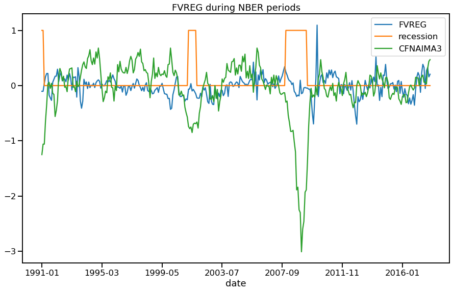

```python
fig, axs = plt.subplots(1,1,figsize=(15,9))
FVREG_vs_NBREG.plot(ax=axs, title='FVREG during NBER periods')
```

## Graph showing the evolution of 1 USD invested in FVREG and some other factors

```python
FVREG.index = FVREG.date
FVREG.drop(columns='date', inplace=True)
```

```python
def monthualize(data):
    return (1 + data)**(1/12)-1
FVREG_month = monthualize(FVREG)
```

```python
cumulative_ret_FVREG = (1 + FVREG_month).cumprod()
```

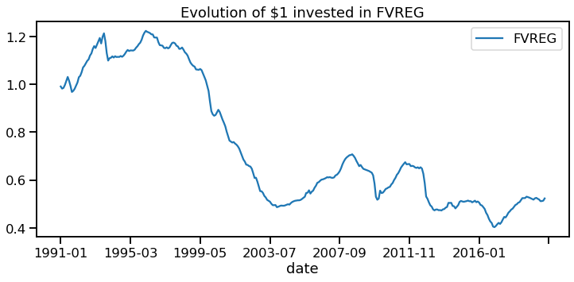

```python
sns.set_context('talk')
fig, axs = plt.subplots(1,1,figsize=(12,5))
cumulative_ret_FVREG.plot(ax=axs, title='Evolution of $1 invested in FVREG')
```

```python
dhs_factor_month = monthualize(dhs_factor)
```

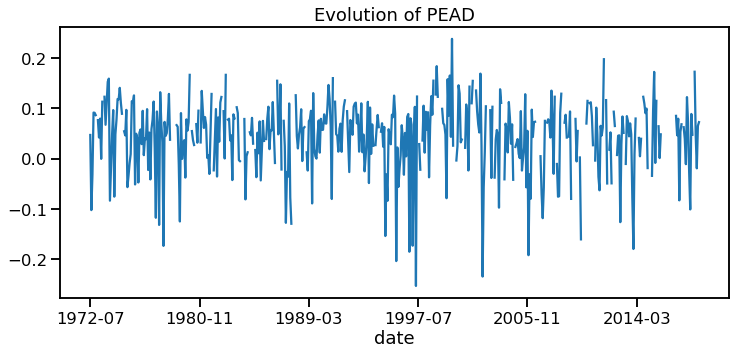

```python
fig, axs = plt.subplots(1,1,figsize=(12,5))

dhs_factor_month.PEAD.plot(ax=axs, title='Evolution of PEAD')
```

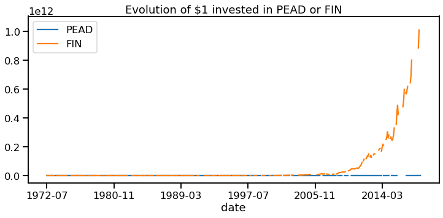

```python
#factor_models = {'dhs_factor' : dhs_factor , 'q5_factors' : q5_factors, 'misp_prices' : misp_prices, 'fama_french_5' : fama_french_5}
cumulative_ret_PEAD = (1 + dhs_factor_month).cumprod()
sns.set_context('talk')
fig, axs = plt.subplots(1,1,figsize=(12,5))
cumulative_ret_PEAD.plot(ax=axs, title='Evolution of $1 invested in PEAD or FIN')
```

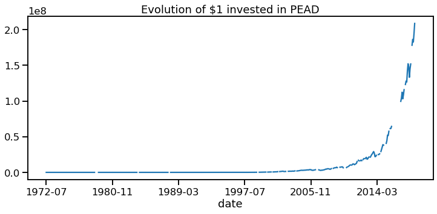

```python
fig, axs = plt.subplots(1,1,figsize=(12,5))

cumulative_ret_PEAD['PEAD'].plot(ax=axs, title='Evolution of $1 invested in PEAD')
```